# Single-Layer Networks - Part2

### Lecture Date: 2025-02-07

# PyTorch Setup for Neural Networks

```python
# Core Boilerplate Imports for PyTorch/Lightning
import numpy as np
import torch
import lightning.pytorch as pl
from torchinfo import summary
from torchview import draw_graph
import torchmetrics
import matplotlib.pyplot as plt
```

```python
print("GPU is present:",torch.cuda.is_available())
```

```
GPU is present: False
```

# Standard data set preparations

1. Create matrix of feature vectors (all but last column)
2. Create vector of class labels (last column only)

```python
data = np.loadtxt("https://jupyterhub.cs.mtsu.edu/azuread/services/csci4850-materials/public/iris-data.txt")
```

```python
data.shape
```

```
(150, 5)
```

```python
X = data[:,:-1]
X.shape
```

```
(150, 4)
```

```python
Y = data[:,-1:]
Y.shape
```

```
(150, 1)
```

### Integer Representation

```python
Y[0:5]
```

```
array([[1.],
       [2.],
       [2.],
       [1.],
       [0.]])
```

```python
X[0:5]
```

```
array([[5.8, 2.7, 3.9, 1.2],
       [6.9, 3.1, 5.4, 2.1],
       [7.7, 3. , 6.1, 2.3],
       [5.7, 3. , 4.2, 1.2],
       [5.1, 3.7, 1.5, 0.4]])
```

### One-hot Representation

```python
np.eye(len(np.unique(Y)))[Y[0:5,-1].astype(int)]
```

```
array([[0., 1., 0.],
       [0., 0., 1.],
       [0., 0., 1.],
       [0., 1., 0.],
       [1., 0., 0.]])
```

# Neural Network - Input Layer Only

```python
# Define model - Input Layer ONLY
class NeuralNetwork(pl.LightningModule):
    def __init__(self, **kwargs):
        super().__init__(**kwargs)

    def forward(self, x):
        y = x
        return y

model = NeuralNetwork()
print(model)
```

```
NeuralNetwork()
```

Passing data into the network (and getting back the result).

```python
model(torch.tensor(X[0:5]).to(torch.float32))
```

```
tensor([[5.8000, 2.7000, 3.9000, 1.2000],
        [6.9000, 3.1000, 5.4000, 2.1000],
        [7.7000, 3.0000, 6.1000, 2.3000],
        [5.7000, 3.0000, 4.2000, 1.2000],
        [5.1000, 3.7000, 1.5000, 0.4000]])
```

# Net Visualization/Summaries

```python
model_graph = draw_graph(model,
                         input_size=X[0:5].shape,
                         depth=2)
model_graph.visual_graph
```

[figure not shown]

```python
summary(model, input_size=X[0:5].shape)
```

```
==========================================================================================
Layer (type:depth-idx)                   Output Shape              Param #
==========================================================================================
NeuralNetwork                            [5, 4]                    --
==========================================================================================
Total params: 0
Trainable params: 0
Non-trainable params: 0
Total mult-adds (Units.MEGABYTES): 0
==========================================================================================
Input size (MB): 0.00
Forward/backward pass size (MB): 0.00
Params size (MB): 0.00
Estimated Total Size (MB): 0.00
==========================================================================================
```

# Add Ouput Layer

### Softmax Activation Function

```python
# Define model
class NeuralNetwork(pl.LightningModule):
    def __init__(self, **kwargs):
        super().__init__(**kwargs)
        self.net_input = torch.nn.Linear(4,3)
        self.activation = torch.nn.Softmax(dim=-1)
        self.c_acc = torchmetrics.classification.Accuracy(task='multiclass',
                                                          num_classes=3)
        self.cce_loss = torch.nn.CrossEntropyLoss()

    def forward(self, x):
        y = x
        y = self.net_input(y)
        return y

    def configure_optimizers(self):
        optimizer = torch.optim.SGD(self.parameters(), lr=10.0)
        return optimizer

    def predict_step(self, pred_batch, batch_idx):
        x, y_true = pred_batch
        y_pred = self(x)
        return self.activation(y_pred), y_true

    def training_step(self, train_batch, batch_idx):
        x, y_true = train_batch
        y_pred = self(x)
        acc = self.c_acc(y_pred,y_true)
        loss = self.cce_loss(y_pred,y_true)
        self.log('train_acc', acc, on_step=False, on_epoch=True)
        self.log('train_loss', loss, on_step=False, on_epoch=True)
        return loss

    def validation_step(self, val_batch, batch_idx):
        x, y_true = val_batch
        y_pred = self(x)
        acc = self.c_acc(y_pred,y_true)
        loss = self.cce_loss(y_pred,y_true)
        self.log('val_acc', acc, on_step=False, on_epoch=True)
        self.log('val_loss', loss, on_step=False, on_epoch=True)
        return loss

model = NeuralNetwork()
print(model)
```

```
NeuralNetwork(
  (net_input): Linear(in_features=4, out_features=3, bias=True)
  (activation): Softmax(dim=-1)
  (c_acc): MulticlassAccuracy()
  (cce_loss): CrossEntropyLoss()
)
```

```python
model(torch.tensor(X[0:5]).to(torch.float32)).detach().numpy()
```

```
array([[-0.8794331 , -0.40310088,  1.0063894 ],
       [-1.372686  , -0.393166  ,  0.8837476 ],
       [-1.4099764 , -0.32574266,  0.8201244 ],
       [-1.0252413 , -0.6134119 ,  1.0367587 ],
       [-0.60078144, -0.42051303,  1.6093402 ]], dtype=float32)
```

```python
model.activation(model(torch.tensor(X[0:5]).to(torch.float32))).detach().numpy()
```

```
array([[0.10867283, 0.17498043, 0.71634674],
       [0.07568792, 0.20157033, 0.7227418 ],
       [0.0754263 , 0.22304857, 0.7015251 ],
       [0.09642037, 0.14555393, 0.7580257 ],
       [0.08838322, 0.10584231, 0.8057744 ]], dtype=float32)
```

```python
summary(model, input_size=X[0:5].shape)
```

```
==========================================================================================
Layer (type:depth-idx)                   Output Shape              Param #
==========================================================================================
NeuralNetwork                            [5, 3]                    --
├─Linear: 1-1                            [5, 3]                    15
==========================================================================================
Total params: 15
Trainable params: 15
Non-trainable params: 0
Total mult-adds (Units.MEGABYTES): 0.00
==========================================================================================
Input size (MB): 0.00
Forward/backward pass size (MB): 0.00
Params size (MB): 0.00
Estimated Total Size (MB): 0.00
==========================================================================================
```

```python
model_graph = draw_graph(model,
                         input_size=X[0:5].shape,
                         depth=1)
model_graph.visual_graph
```

[figure not shown]

```python
Y.shape
```

```
(150, 1)
```

```python
Y[0:5]
```

```
array([[1.],
       [2.],
       [2.],
       [1.],
       [0.]])
```

```python
model(torch.tensor(X[0:5]).to(torch.float32).to(model.device)).cpu().detach().numpy()
```

```
array([[-0.8794331 , -0.40310088,  1.0063894 ],
       [-1.372686  , -0.393166  ,  0.8837476 ],
       [-1.4099764 , -0.32574266,  0.8201244 ],
       [-1.0252413 , -0.6134119 ,  1.0367587 ],
       [-0.60078144, -0.42051303,  1.6093402 ]], dtype=float32)
```

```python
model.activation(model(torch.tensor(X[0:5]).to(torch.float32).to(model.device))).cpu().detach().numpy()
```

```
array([[0.10867283, 0.17498043, 0.71634674],
       [0.07568792, 0.20157033, 0.7227418 ],
       [0.0754263 , 0.22304857, 0.7015251 ],
       [0.09642037, 0.14555393, 0.7580257 ],
       [0.08838322, 0.10584231, 0.8057744 ]], dtype=float32)
```

```python
model(torch.tensor(X[0:5]).to(torch.float32).to(model.device)).cpu().detach().numpy().argmax(-1)
```

```
array([2, 2, 2, 2, 2])
```

# Evaluation Metrics

```python
len(np.unique(Y))
```

```
3
```

```python
categorical_accuracy = torchmetrics.classification.Accuracy(task='multiclass',
                                                           num_classes=3)
```

```python
y_pred = model(torch.tensor(X[0:5]).to(torch.float32).to(model.device)).cpu()
y_true = torch.tensor(Y[0:5]).to(torch.long)[:,-1]
```

```python
y_pred
```

```
tensor([[-0.8794, -0.4031,  1.0064],
        [-1.3727, -0.3932,  0.8837],
        [-1.4100, -0.3257,  0.8201],
        [-1.0252, -0.6134,  1.0368],
        [-0.6008, -0.4205,  1.6093]], grad_fn=<AddmmBackward0>)
```

```python
torch.argmax(y_pred,-1)
```

```
tensor([2, 2, 2, 2, 2])
```

```python
y_true
```

```
tensor([1, 2, 2, 1, 0])
```

```python
categorical_accuracy(y_pred,y_true)
```

```
tensor(0.4000)
```

### Loss - How uncertain is the net?

```python
torch.nn.functional.cross_entropy(y_pred,y_true)
```

```
tensor(1.3551, grad_fn=<NllLossBackward0>)
```

```python
torch.nn.functional.cross_entropy(y_pred,y_true,
                                  reduction="none")
```

```
tensor([1.7431, 0.3247, 0.3545, 1.9272, 2.4261], grad_fn=<NllLossBackward0>)
```

```python
model.cce_loss(y_pred,y_true)
```

```
tensor(1.3551, grad_fn=<NllLossBackward0>)
```

# PyTorch Lightning (Complete Pipeline)

Complete Training Regime for Iris (for *Multiclass Classification*)

```python
# Define model
class NeuralNetwork(pl.LightningModule):
    def __init__(self, **kwargs):
        super().__init__(**kwargs)
        self.net_input = torch.nn.Linear(4,3)
        self.activation = torch.nn.Softmax(dim=-1)
        self.c_acc = torchmetrics.classification.Accuracy(task='multiclass',
                                                          num_classes=3)
        self.cce_loss = torch.nn.CrossEntropyLoss()

    def forward(self, x):
        y = x
        y = self.net_input(y)
        return y

    def configure_optimizers(self):
        optimizer = torch.optim.SGD(self.parameters(), lr=10.0)
        return optimizer

    def predict_step(self, pred_batch, batch_idx):
        x, y_true = pred_batch
        y_pred = self(x)
        return self.activation(y_pred), y_true

    def training_step(self, train_batch, batch_idx):
        x, y_true = train_batch
        y_pred = self(x)
        acc = self.c_acc(y_pred,y_true)
        loss = self.cce_loss(y_pred,y_true)
        self.log('train_acc', acc, on_step=False, on_epoch=True)
        self.log('train_loss', loss, on_step=False, on_epoch=True)
        return loss

    def validation_step(self, val_batch, batch_idx):
        x, y_true = val_batch
        y_pred = self(x)
        acc = self.c_acc(y_pred,y_true)
        loss = self.cce_loss(y_pred,y_true)
        self.log('val_acc', acc, on_step=False, on_epoch=True)
        self.log('val_loss', loss, on_step=False, on_epoch=True)
        return loss

model = NeuralNetwork()
print(model)
```

```
NeuralNetwork(
  (net_input): Linear(in_features=4, out_features=3, bias=True)
  (activation): Softmax(dim=-1)
  (c_acc): MulticlassAccuracy()
  (cce_loss): CrossEntropyLoss()
)
```

# Data Module Preparation

Data modules wrap up the data preparation process into a concise/transportable code for preparing data sets, and provides functions for automatically retrieving the needed `DataLoader` objects during `fit/validate/test/predict` calls to the `Trainer`.

```python
class MulticlassClassificationDataModule(pl.LightningDataModule):
    def __init__(self,
                 data_url = "https://jupyterhub.cs.mtsu.edu/azuread/services/csci4850-materials/public/iris-data.txt",
                 batch_size = 32,
                 val_split = 0.2,
                 num_workers = 4,
                 **kwargs):
        super().__init__(**kwargs)
        self.data_url = data_url
        self.batch_size = batch_size
        self.val_split = val_split
        self.num_workers = num_workers
        self.data_train = None
        self.data_val = None

    def setup(self, stage: str):
        if (stage == 'fit' or \
            stage == 'validate' or \
            stage == 'predict') and \
            not(self.data_train and self.data_val):
            rng = np.random.default_rng()
            data = np.loadtxt(self.data_url)
            rng.shuffle(data)
            split_point = int(data.shape[0]*(1.0-self.val_split))
            self.data_train = list(zip(torch.tensor(data[:split_point,:-1]).to(torch.float32),
                                       torch.tensor(data[:split_point,-1]).to(torch.long)))
            self.data_val = list(zip(torch.tensor(data[split_point:,:-1]).to(torch.float32),
                                     torch.tensor(data[split_point:,-1]).to(torch.long)))

    def train_dataloader(self):
        return torch.utils.data.DataLoader(self.data_train,
                                           batch_size=self.batch_size,
                                           num_workers=self.num_workers,
                                           shuffle=True)

    def val_dataloader(self):
        return torch.utils.data.DataLoader(self.data_val,
                                           batch_size=self.batch_size,
                                           num_workers=self.num_workers,
                                           shuffle=False)

    def predict_dataloader(self):
        return torch.utils.data.DataLoader(self.data_val,
                                           batch_size=self.batch_size,
                                           num_workers=self.num_workers,
                                           shuffle=False)
```

```python
iris_datamodule = MulticlassClassificationDataModule()
```

Let's explore this object for a moment, but keep in mind that we normally would *not use the datamodule like this directly*. Instead, the `setup` and `train_dataloader` functions will be called by the `Trainer` when they are needed.

```python
iris_datamodule.setup('fit')
xy_train = iris_datamodule.train_dataloader()
xy_val = iris_datamodule.val_dataloader()
```

```python
batch = next(iter(xy_train))
batch
```

```
[tensor([[5.8000, 2.7000, 4.1000, 1.0000],
         [6.3000, 2.5000, 4.9000, 1.5000],
         [6.4000, 3.2000, 5.3000, 2.3000],
         [5.0000, 3.6000, 1.4000, 0.2000],
         [6.2000, 3.4000, 5.4000, 2.3000],
         [4.8000, 3.0000, 1.4000, 0.3000],
         [4.9000, 2.4000, 3.3000, 1.0000],
         [4.9000, 2.5000, 4.5000, 1.7000],
         [7.7000, 3.0000, 6.1000, 2.3000],
         [6.7000, 2.5000, 5.8000, 1.8000],
         [5.7000, 2.8000, 4.5000, 1.3000],
         [7.1000, 3.0000, 5.9000, 2.1000],
         [6.2000, 2.9000, 4.3000, 1.3000],
         [7.2000, 3.0000, 5.8000, 1.6000],
         [4.6000, 3.4000, 1.4000, 0.3000],
         [5.1000, 3.8000, 1.6000, 0.2000],
         [5.5000, 3.5000, 1.3000, 0.2000],
         [5.0000, 3.5000, 1.3000, 0.3000],
         [6.0000, 2.9000, 4.5000, 1.5000],
         [5.8000, 2.7000, 5.1000, 1.9000],
         [5.5000, 4.2000, 1.4000, 0.2000],
         [7.9000, 3.8000, 6.4000, 2.0000],
         [5.2000, 4.1000, 1.5000, 0.1000],
         [6.0000, 2.2000, 5.0000, 1.5000],
         [5.8000, 2.7000, 3.9000, 1.2000],
         [6.1000, 2.9000, 4.7000, 1.4000],
         [6.8000, 2.8000, 4.8000, 1.4000],
         [6.1000, 2.8000, 4.7000, 1.2000],
         [5.4000, 3.9000, 1.7000, 0.4000],
         [6.7000, 3.3000, 5.7000, 2.5000],
         [6.3000, 3.3000, 4.7000, 1.6000],
         [5.6000, 2.8000, 4.9000, 2.0000]]),
 tensor([1, 1, 2, 0, 2, 0, 1, 2, 2, 2, 1, 2, 1, 2, 0, 0, 0, 0, 1, 2, 0, 2, 0, 2,
         1, 1, 1, 1, 0, 2, 1, 2])]
```

```python
type(batch)
```

```
list
```

```python
len(batch)
```

```
2
```

# PyTorch Lightning

### Loggers and Trainers

```python
logger = pl.loggers.CSVLogger("logs",name="iris_single_layer",)
trainer = pl.Trainer(max_epochs=100,logger=logger,
                     enable_progress_bar=True,
                     log_every_n_steps=0,
                     callbacks=[pl.callbacks.TQDMProgressBar(refresh_rate=20)])
```

```
GPU available: False, used: False
TPU available: False, using: 0 TPU cores
HPU available: False, using: 0 HPUs
```

```python
result = trainer.validate(model, iris_datamodule)
```

```
Validation: |          | 0/? [00:00<?, ?it/s]
```

```
┏━━━━━━━━━━━━━━━━━━━━━━━━━━━┳━━━━━━━━━━━━━━━━━━━━━━━━━━━┓
┃      Validate metric      ┃       DataLoader 0        ┃
┡━━━━━━━━━━━━━━━━━━━━━━━━━━━╇━━━━━━━━━━━━━━━━━━━━━━━━━━━┩
│          val_acc          │    0.7666666507720947     │
│         val_loss          │    1.0165773630142212     │
└───────────────────────────┴───────────────────────────┘
```

```python
result
```

```
[{'val_acc': 0.7666666507720947, 'val_loss': 1.0165773630142212}]
```

```python
result[0]['val_loss']
```

```
1.0165773630142212
```

```python
result[0]['val_acc']
```

```
0.7666666507720947
```

```python
result = trainer.fit(model,
                     iris_datamodule)
```

```
  | Name       | Type               | Params | Mode
----------------------------------------------------------
0 | net_input  | Linear             | 15     | train
1 | activation | Softmax            | 0      | train
2 | c_acc      | MulticlassAccuracy | 0      | train
3 | cce_loss   | CrossEntropyLoss   | 0      | train
----------------------------------------------------------
15        Trainable params
0         Non-trainable params
15        Total params
0.000     Total estimated model params size (MB)
4         Modules in train mode
0         Modules in eval mode
```

```
Sanity Checking: |          | 0/? [00:00<?, ?it/s]
```

```
Training: |          | 0/? [00:00<?, ?it/s]
```

[output not shown]

[output not shown]

[output not shown]

[output not shown]

[output not shown]

[output not shown]

[output not shown]

[output not shown]

[output not shown]

[output not shown]

[output not shown]

[output not shown]

[output not shown]

[output not shown]

[output not shown]

[output not shown]

[output not shown]

[output not shown]

[output not shown]

[output not shown]

[output not shown]

[output not shown]

[output not shown]

[output not shown]

[output not shown]

[output not shown]

[output not shown]

[output not shown]

[output not shown]

[output not shown]

[output not shown]

[output not shown]

[output not shown]

[output not shown]

[output not shown]

[output not shown]

[output not shown]

[output not shown]

[output not shown]

[output not shown]

[output not shown]

[output not shown]

[output not shown]

[output not shown]

[output not shown]

[output not shown]

[output not shown]

[output not shown]

[output not shown]

[output not shown]

[output not shown]

[output not shown]

[output not shown]

[output not shown]

[output not shown]

[output not shown]

[output not shown]

[output not shown]

[output not shown]

[output not shown]

[output not shown]

[output not shown]

[output not shown]

[output not shown]

[output not shown]

[output not shown]

[output not shown]

[output not shown]

[output not shown]

[output not shown]

[output not shown]

[output not shown]

[output not shown]

[output not shown]

[output not shown]

[output not shown]

[output not shown]

[output not shown]

[output not shown]

[output not shown]

[output not shown]

[output not shown]

[output not shown]

[output not shown]

[output not shown]

[output not shown]

[output not shown]

[output not shown]

[output not shown]

[output not shown]

[output not shown]

[output not shown]

[output not shown]

[output not shown]

[output not shown]

[output not shown]

[output not shown]

[output not shown]

[output not shown]

[output not shown]

```
`Trainer.fit` stopped: `max_epochs=100` reached.
```

```python
result = trainer.validate(model, iris_datamodule)
```

```
Validation: |          | 0/? [00:00<?, ?it/s]
```

```
┏━━━━━━━━━━━━━━━━━━━━━━━━━━━┳━━━━━━━━━━━━━━━━━━━━━━━━━━━┓
┃      Validate metric      ┃       DataLoader 0        ┃
┡━━━━━━━━━━━━━━━━━━━━━━━━━━━╇━━━━━━━━━━━━━━━━━━━━━━━━━━━┩
│          val_acc          │    0.9666666388511658     │
│         val_loss          │    0.36718156933784485    │
└───────────────────────────┴───────────────────────────┘
```

```python
result
```

```
[{'val_acc': 0.9666666388511658, 'val_loss': 0.36718156933784485}]
```

```python
result[0]['val_acc']
```

```
0.9666666388511658
```

```python
trainer.predict(model, iris_datamodule)
```

```
Predicting: |          | 0/? [00:00<?, ?it/s]
```

```
[(tensor([[1.0000e+00, 0.0000e+00, 0.0000e+00],
          [0.0000e+00, 1.0000e+00, 3.1955e-41],
          [0.0000e+00, 1.0000e+00, 0.0000e+00],
          [0.0000e+00, 1.0000e+00, 0.0000e+00],
          [0.0000e+00, 1.0000e+00, 0.0000e+00],
          [1.0000e+00, 0.0000e+00, 0.0000e+00],
          [1.0000e+00, 1.0955e-40, 0.0000e+00],
          [0.0000e+00, 2.8465e-31, 1.0000e+00],
          [0.0000e+00, 1.0000e+00, 0.0000e+00],
          [0.0000e+00, 1.0000e+00, 0.0000e+00],
          [0.0000e+00, 1.0000e+00, 0.0000e+00],
          [1.0000e+00, 0.0000e+00, 0.0000e+00],
          [0.0000e+00, 1.0000e+00, 0.0000e+00],
          [0.0000e+00, 9.9998e-01, 1.6446e-05],
          [0.0000e+00, 1.0000e+00, 0.0000e+00],
          [0.0000e+00, 0.0000e+00, 1.0000e+00],
          [0.0000e+00, 1.0000e+00, 0.0000e+00],
          [0.0000e+00, 1.0000e+00, 1.3178e-29],
          [1.0000e+00, 2.3822e-44, 0.0000e+00],
          [0.0000e+00, 0.0000e+00, 1.0000e+00],
          [0.0000e+00, 1.0000e+00, 7.5307e-41],
          [0.0000e+00, 0.0000e+00, 1.0000e+00],
          [1.0000e+00, 0.0000e+00, 0.0000e+00],
          [1.0000e+00, 2.0777e-32, 0.0000e+00],
          [1.0000e+00, 3.9161e-40, 0.0000e+00],
          [0.0000e+00, 1.0000e+00, 0.0000e+00],
          [0.0000e+00, 1.0843e-41, 1.0000e+00],
          [1.0000e+00, 9.1492e-31, 0.0000e+00],
          [0.0000e+00, 5.0748e-37, 1.0000e+00],
          [1.0000e+00, 0.0000e+00, 0.0000e+00]]),
  tensor([0, 1, 1, 1, 1, 0, 0, 2, 1, 1, 1, 0, 1, 2, 1, 2, 1, 1, 0, 2, 1, 2, 0, 0,
          0, 1, 2, 0, 2, 0]))]
```

# Plotting Learning Curves

```python
import pandas as pd
```

```python
results = pd.read_csv(logger.log_dir+"/metrics.csv",delimiter=',')
```

```python
results
```

|  | epoch | step | train_acc | train_loss | val_acc | val_loss |
| --- | --- | --- | --- | --- | --- | --- |
| 0 | 0 | 0 | NaN | NaN | 0.766667 | 1.016577 |
| 1 | 0 | 3 | NaN | NaN | 0.233333 | 305.932007 |
| 2 | 0 | 3 | 0.416667 | 108.735260 | NaN | NaN |
| 3 | 1 | 7 | NaN | NaN | 0.233333 | 247.015854 |
| 4 | 1 | 7 | 0.400000 | 156.288513 | NaN | NaN |
| ... | ... | ... | ... | ... | ... | ... |
| 197 | 98 | 395 | NaN | NaN | 0.966667 | 0.519650 |
| 198 | 98 | 395 | 0.941667 | 1.487034 | NaN | NaN |
| 199 | 99 | 399 | NaN | NaN | 0.966667 | 0.367182 |
| 200 | 99 | 399 | 0.950000 | 1.494529 | NaN | NaN |
| 201 | 100 | 400 | NaN | NaN | 0.966667 | 0.367182 |

202 rows × 6 columns

```python
results['epoch']
```

```
0        0
1        0
2        0
3        1
4        1
      ...
197     98
198     98
199     99
200     99
201    100
Name: epoch, Length: 202, dtype: int64
```

```python
results['train_loss']
```

```
0             NaN
1             NaN
2      108.735260
3             NaN
4      156.288513
          ...
197           NaN
198      1.487034
199           NaN
200      1.494529
201           NaN
Name: train_loss, Length: 202, dtype: float64
```

```python
results['val_loss']
```

```
0        1.016577
1      305.932007
2             NaN
3      247.015854
4             NaN
          ...
197      0.519650
198           NaN
199      0.367182
200           NaN
201      0.367182
Name: val_loss, Length: 202, dtype: float64
```

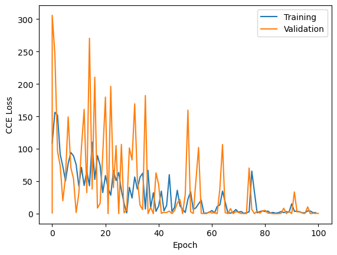

```python
plt.plot(results["epoch"][np.logical_not(np.isnan(results["train_loss"]))],
         results["train_loss"][np.logical_not(np.isnan(results["train_loss"]))],
         label="Training")
plt.plot(results["epoch"][np.logical_not(np.isnan(results["val_loss"]))],
         results["val_loss"][np.logical_not(np.isnan(results["val_loss"]))],
         label="Validation")
plt.legend()
plt.ylabel("CCE Loss")
plt.xlabel("Epoch")
plt.show()
```

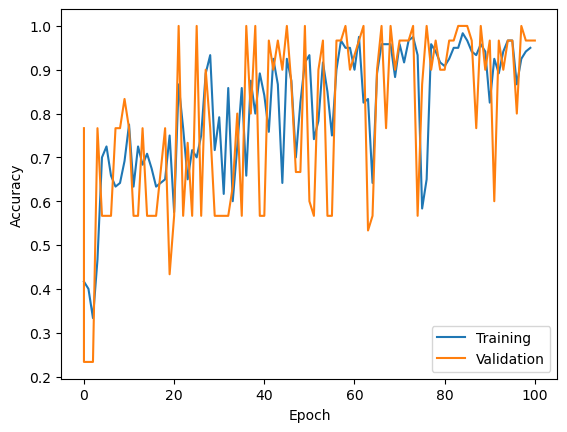

```python
plt.plot(results["epoch"][np.logical_not(np.isnan(results["train_acc"]))],
         results["train_acc"][np.logical_not(np.isnan(results["train_acc"]))],
         label="Training")
plt.plot(results["epoch"][np.logical_not(np.isnan(results["val_acc"]))],
         results["val_acc"][np.logical_not(np.isnan(results["val_acc"]))],
         label="Validation")
plt.legend()
plt.ylabel("Accuracy")
plt.xlabel("Epoch")
plt.show()
```

```python
val_pred = trainer.predict(model, iris_datamodule)
```

```
Predicting: |          | 0/? [00:00<?, ?it/s]
```

```python
y_pred = torch.cat([x[0] for x in val_pred]).detach().numpy().argmax(-1)
y_true = torch.cat([x[1] for x in val_pred]).flatten().detach().numpy()
```

```python
y_pred
```

```
array([0, 1, 1, 1, 1, 0, 0, 2, 1, 1, 1, 0, 1, 1, 1, 2, 1, 1, 0, 2, 1, 2,
       0, 0, 0, 1, 2, 0, 2, 0])
```

```python
y_true
```

```
array([0, 1, 1, 1, 1, 0, 0, 2, 1, 1, 1, 0, 1, 2, 1, 2, 1, 1, 0, 2, 1, 2,
       0, 0, 0, 1, 2, 0, 2, 0])
```

```python
np.where(y_pred.astype(int) != y_true.astype(int))[0]
```

```
array([13])
```

```python
len(np.where(y_pred.astype(int) == y_true.astype(int))[0])
```

```
29
```

```python
y_pred.shape[0]
```

```
30
```

```python
len(np.where(y_pred.astype(int) == y_true.astype(int))[0]) / y_pred.shape[0]
```

```
0.9666666666666667
```

One final check...

```python
result = trainer.validate(model, iris_datamodule)
```

```
Validation: |          | 0/? [00:00<?, ?it/s]
```

```
┏━━━━━━━━━━━━━━━━━━━━━━━━━━━┳━━━━━━━━━━━━━━━━━━━━━━━━━━━┓
┃      Validate metric      ┃       DataLoader 0        ┃
┡━━━━━━━━━━━━━━━━━━━━━━━━━━━╇━━━━━━━━━━━━━━━━━━━━━━━━━━━┩
│          val_acc          │    0.9666666388511658     │
│         val_loss          │    0.36718156933784485    │
└───────────────────────────┴───────────────────────────┘
```

```python
print(result[0]['val_acc'])
```

```
0.9666666388511658
```

Raw data reported every 10 epochs...

```python
print("Validation accuracy:",*["%.8f"%(x) for x in
                               results['val_acc'][np.logical_not(np.isnan(results["val_acc"]))][0::10]])
```

```
Validation accuracy: 0.76666665 0.83333331 0.43333334 0.56666666 0.56666666 1.00000000 0.89999998 0.89999998 0.89999998 0.89999998 0.96666664
```